# Albacore Diet Synthesis Rarefaction

Natasha Hardy

20/10/2021

## About

Illustrating the biological diversity in diets of a highly migratory predator, albacore tuna, across ocean basins and years sampled. We collected historical data on albacore tuna stomach contents, and plot the mean and cumulative species richness obtained with each additional data collection effort.

## Workspace

```r
#R documentation
library(pander)
library(formatR)

# general
library(tidyverse)
library(readxl)
library(readr)
library(plyr)
library(dplyr)
library(here)
"%notin%" = Negate('%in%')
here::here()
```

```
## [1] "/Users/tashhardy/Documents/GitHub/albacore-diet-global"
```

```r
# Graphics
library(ggplot2)

# Biodiversity & analyses
library(BiodiversityR)
library(vegan)
library(tcltk)

#How many of these packages do we really need?
#library(viridis)
#library(RColorBrewer)
#library(wesanderson)
#library(devtools)
```

## Species community data

```r
# Data -- using total diet data
alb_global_dietpa = read.csv(here("data/2_output_data/alb_global_wide_dietpa.csv"),
    check.names = FALSE) %>%
    group_by(OceanBasin) %>%
    arrange(YearEnd)

## Albacore prey species P/A data data
PreyPAdata = as.data.frame(alb_global_dietpa[, 10:ncol(alb_global_dietpa)])
PreyPAsite = as.data.frame(alb_global_dietpa[, c(1:5)])

# str(PreyPAdata)
str(PreyPAsite)
```

```
## 'data.frame':    69 obs. of  5 variables:
##  $ StudyID    : chr  "Jordan1880" "Monaco1888" "Joubin1918" "Bouxin&Legendre" ...
##  $ rep_ID     : chr  "Jordan1880_41" "Monaco1888_46" "Joubin1918_42" "Bouxin&Legendre_5" ...
##  $ YearEnd    : int  1880 1888 1918 1928 1929 1930 1931 1932 1933 1941 ...
##  $ OceanBasin : chr  "N Pacific" "Mediterranean" "N Atlantic" "N Atlantic" ...
##  $ OceanBasinQ: chr  "NE Pacific" "Mediterranean" "NE Atlantic" "NE Atlantic" ...
```

```r
rownames(PreyPAsite) = rownames(PreyPAdata)

# check.datasets(PreyPAdata, PreyPAsite) ensure that the sites of the community
# dataset are the same sites as those from the environmental dataset -->
# something that is assumed to be the case for the BiodiversityR and vegan
# packages.

# Save data if needed write.csv(PreyPAsite,
# here('data/output_data/alb_global_rarefactiondata.csv'), row.names = FALSE)
```

```r
# PreyPAsite =
# read.csv(here('data/output_data/alb_global_rarefactiondata.csv'), check.names
# = FALSE)

PreyPAsite$YearEnd = as.integer(PreyPAsite$YearEnd)
PreyPAsite$StudyID = as.factor(PreyPAsite$StudyID)
PreyPAsite$OceanBasin = as.factor(PreyPAsite$OceanBasin)
```

Species richness per ocean basin:

```r
# number of species and the factor that I want to group them by
SpO <- specnumber(PreyPAdata, PreyPAsite$OceanBasin)
SpO
```

```
##        Indian Mediterranean    N Atlantic     N Pacific    S Atlantic
##            79            38           107           123            56
##     S Pacific
##            14
```

## Mean Cumulative Richness

Species mean species accumulation overall:

Makes a dataset with species richness in relation to sites using the ‘exact’ method. This adds sites randomly, and finds the expected mean number of sites that contribute to a certain increase in species richness.

```r
Alb.mean.1 <- accumresult(PreyPAdata, y = PreyPAsite$OceanBasin, method = "exact",
    conditioned = TRUE)
glimpse(Alb.mean.1)
```

```
## List of 7
##  $ call    : language specaccum(comm = x, method = method, permutations = permutations, conditioned = conditioned,      gamma = gamma)
##  $ method  : chr "exact"
##  $ sites   : int [1:69] 1 2 3 4 5 6 7 8 9 10 ...
##  $ richness: num [1:69] 14.3 27.4 39.4 50.5 60.8 ...
##  $ sd      : num [1:69] 15.5 20.8 24.3 26.8 28.7 ...
##  $ perm    : NULL
##  $ freq    : Named num [1:308] 1 1 6 1 3 3 1 2 3 1 ...
##   ..- attr(*, "names")= chr [1:308] "Abralia redfieldi" "Abraliopsis affinis" "Abraliopsis felis" "Abraliopsis gilchristi" ...
##  - attr(*, "class")= chr "specaccum"
```

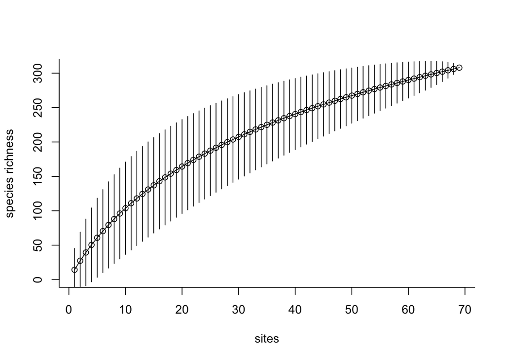

```r
accumplot(Alb.mean.1)
```

Mean cumulative richness in relation to Ocean Basin sampled:

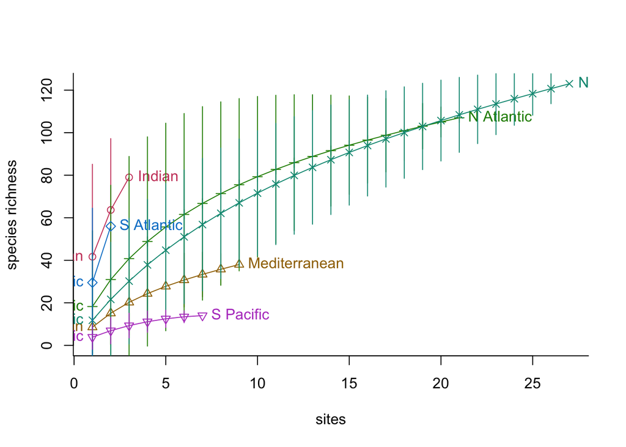

```r
# With automatic plotting
Alb.mean.2 <- accumcomp(PreyPAdata, y = PreyPAsite, factor = "OceanBasin", method = "exact",
    legend = FALSE, conditioned = TRUE)  #, scale='YearEnd'
```

```r
# Withhold on plotting so as to do so in ggplot
Alb.mean.3 <- accumcomp(PreyPAdata, y = PreyPAsite, factor = "OceanBasin", method = "exact",
    conditioned = F, plotit = F)

Alb.mean.long3 <- accumcomp.long(Alb.mean.3, ci = NA, label.freq = 5)
```

```r
# possibly need for extrafont::loadfonts(device="win") to have Arial
# as alternative, use library(ggThemeAssist)

BioR.theme <- theme(
  panel.background = element_blank(),
  #panel.border = element_blank(),
  panel.grid = element_blank(),
  axis.line = element_line("gray25"),
  text = element_text(size = 24, family="Arial"),
  axis.text = element_text(size = 24, colour = "gray25"),
  axis.title = element_text(size = 24, colour = "gray25"),
  legend.title = element_text(size = 24),
  legend.text = element_text(size = 24),
  legend.key = element_blank(),
  legend.position = c(0.8, 0.3)
  )
```

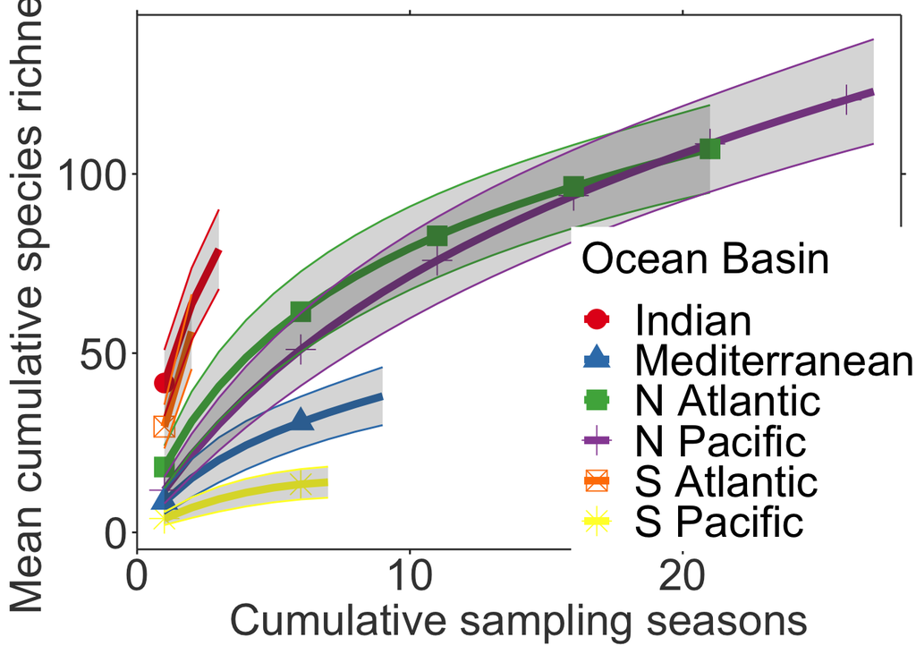

```r
plotgg1 <- ggplot(data = Alb.mean.long3, aes(x = Sites, y = Richness, ymax = UPR,
    ymin = LWR)) + scale_x_continuous(expand = c(0, 1), sec.axis = dup_axis(labels = NULL,
    name = NULL)) + scale_y_continuous(sec.axis = dup_axis(labels = NULL, name = NULL)) +
    # ylim(0,130)+
geom_line(aes(colour = Grouping), size = 2) + geom_point(data = subset(Alb.mean.long3,
    labelit == TRUE), aes(colour = Grouping, shape = Grouping), size = 5) + geom_ribbon(aes(colour = Grouping),
    alpha = 0.2, show.legend = FALSE) + BioR.theme + scale_color_brewer(palette = "Set1") +
    labs(x = "Cumulative sampling seasons", y = "Mean cumulative species richness",
        colour = "Ocean Basin", shape = "Ocean Basin")

plotgg1
```

```r
ggsave(here("outputs_figures/ms_figures/fig1_map_spp/alb_mean_accum_legend.jpeg"),
    plot = plotgg1, height = 8, width = 12, dpi = 300)
```

## Step-wise accumulation by Ocean Basin

```r
Alb.acc.1 <- accumresult(PreyPAdata, y = PreyPAsite$OceanBasin, method = "collector",
    conditioned = TRUE)
Alb.acc.1
```

```
## Species Accumulation Curve
## Accumulation method: collector
## Call: specaccum(comm = x, method = method, permutations = permutations,      conditioned = conditioned, gamma = gamma)
##
##
## Sites    1 2 3 4  5  6  7  8  9 10 11 12 13 14 15  16  17  18  19  20  21  22
## Richness 2 3 8 8 25 33 62 80 91 93 93 94 96 96 97 111 120 134 134 134 139 140
##
## Sites     23  24  25  26  27  28  29  30  31  32  33  34  35  36  37  38  39
## Richness 147 147 155 157 175 175 177 183 183 183 183 183 186 186 194 198 200
##
## Sites     40  41  42  43  44  45  46  47  48  49  50  51  52  53  54  55  56
## Richness 204 204 206 206 206 206 207 212 229 229 229 229 229 229 231 233 233
##
## Sites     57  58  59  60  61  62  63  64  65  66  67  68  69
## Richness 236 236 238 239 239 240 241 241 241 290 295 307 308
```

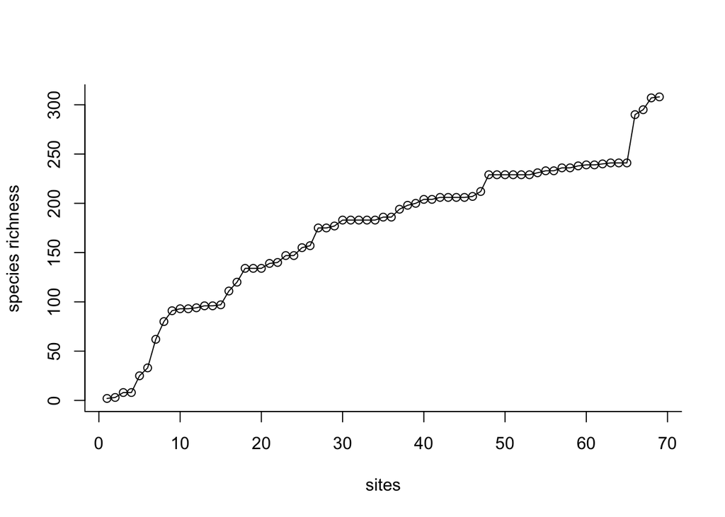

```r
accumplot(Alb.acc.1)
```

```r
str(Alb.acc.1)
```

```
## List of 6
##  $ call    : language specaccum(comm = x, method = method, permutations = permutations, conditioned = conditioned,      gamma = gamma)
##  $ method  : chr "collector"
##  $ sites   : int [1:69] 1 2 3 4 5 6 7 8 9 10 ...
##  $ richness: num [1:69] 2 3 8 8 25 33 62 80 91 93 ...
##  $ sd      : NULL
##  $ perm    : num [1:69, 1] 2 3 8 8 25 33 62 80 91 93 ...
##  - attr(*, "class")= chr "specaccum"
```

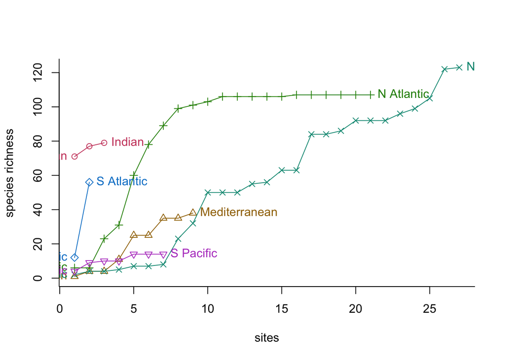

```r
# With automatic plotting
Alb.acc.2 <- accumcomp(PreyPAdata, y = PreyPAsite, factor = "OceanBasin", method = "collector",
    legend = FALSE, conditioned = TRUE)  #, scale='YearEnd'
```

```r
# Withhold on plotting so as to do so in ggplot
Alb.acc.3 <- accumcomp(PreyPAdata, y = PreyPAsite, factor = "OceanBasin", method = "collector",
    conditioned = F, plotit = F)

Alb.acc.long3 <- accumcomp.long(Alb.acc.3, ci = NA, label.freq = 5)
```

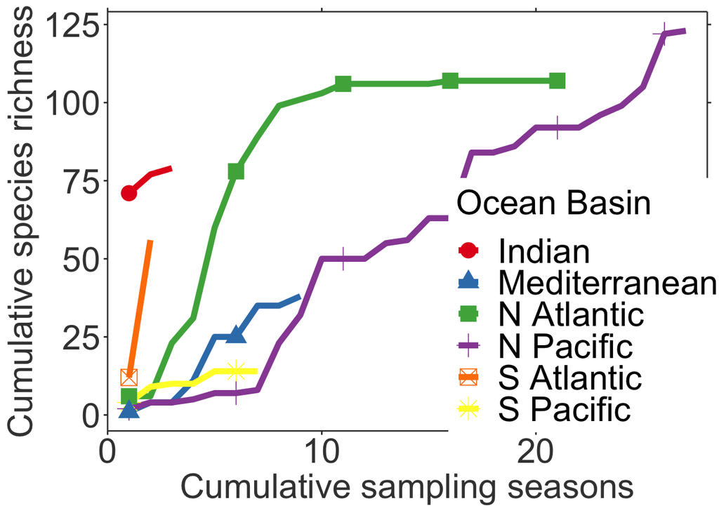

```r
plotgg2 <- ggplot(data = Alb.acc.long3, aes(x = Sites, y = Richness, ymax = UPR,
    ymin = LWR)) + scale_x_continuous(expand = c(0, 1), sec.axis = dup_axis(labels = NULL,
    name = NULL)) + scale_y_continuous(sec.axis = dup_axis(labels = NULL, name = NULL)) +
    geom_line(aes(colour = Grouping), size = 2) + geom_point(data = subset(Alb.acc.long3,
    labelit == TRUE), aes(colour = Grouping, shape = Grouping), size = 5) + BioR.theme +
    scale_color_brewer(palette = "Set1") + labs(x = "Cumulative sampling seasons",
    y = "Cumulative species richness", colour = "Ocean Basin", shape = "Ocean Basin")

plotgg2
```

```r
ggsave(here("outputs_figures/ms_figures/fig1_map_spp/alb_step_accum_simple.jpeg"),
    plot = plotgg2, height = 8, width = 10, dpi = 300)
```

## Step-wise accumulation by Ocean Basin & Year sampled

```r
prey_year = PreyPAsite %>%
  arrange(desc(OceanBasin))

plot2_data = cbind(prey_year, Alb.acc.long3)
```

We need to retroactively append ‘YearEnd’ data to the species accumulation data obtained through Biodiversity R workflow. This code solution was suggest by Roeland Kindt. Both the above and this solution work, as the ‘collector’ method reads in the sites in the order they are sampled, in our case that is chronologically and nested within Ocean Basins.

```r
Alb.acc.long3$Year <- NA
groupings <- unique(Alb.acc.long3$Grouping)

for (g in 1:length(groupings)) {
    group <- groupings[g]
    # assuming Grouping was based on variable Region of the env.data
    Alb.acc.long3[Alb.acc.long3$Grouping == group, "Year"] <- PreyPAsite[PreyPAsite$OceanBasin ==
        group, "YearEnd"]
}
```

```r
#One need to change this if necessary
# possibly need for extrafont::loadfonts(device="win") to have Arial
# as alternative, use library(ggThemeAssist)

BioR.theme3 <- theme(
  panel.background = element_blank(),
  #panel.border = element_blank(),
  panel.grid = element_blank(),
  axis.line = element_line("gray25"),
  text = element_text(size = 24, family="Arial"),
  axis.text = element_text(size = 24, colour = "gray25"),
  axis.title = element_text(size = 24, colour = "gray25"),
  legend.title = element_text(size = 24),
  legend.text = element_text(size = 24),
  legend.key = element_blank(),
  legend.position ="none",
  #legend.position = c(0.2, 0.7)
  )
```

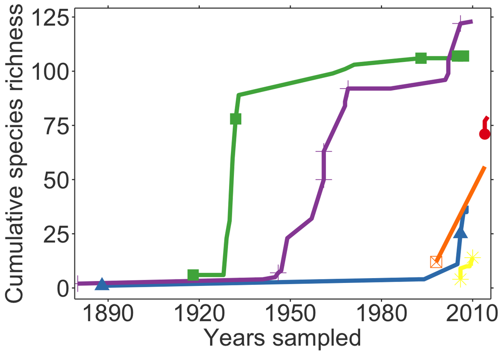

```r
plotgg3 <- ggplot(data = Alb.acc.long3, aes(x = Year, y = Richness, ymax = UPR, ymin = LWR)) +
    scale_x_continuous(expand = c(0, 1), sec.axis = dup_axis(labels = NULL, name = NULL)) +
    scale_y_continuous(sec.axis = dup_axis(labels = NULL, name = NULL)) + geom_line(aes(colour = Grouping),
    size = 2) + geom_point(data = subset(Alb.acc.long3, labelit == TRUE), aes(colour = Grouping,
    shape = Grouping), size = 5) + BioR.theme3 + scale_color_brewer(palette = "Set1") +
    labs(x = "Years sampled", y = "Cumulative species richness", colour = "Ocean Basin",
        shape = "Ocean Basin")

plotgg3
```

```r
ggsave(here("outputs_figures/ms_figures/fig1_map_spp/alb_step_accum_year_nl.jpeg"),
    plot = plotgg3, height = 8, width = 12, dpi = 300)
```

## Extra code

If we want to relevel factors and make our own colour palettes.

```r
levels(as.factor(Alb.acc.long3$Grouping))

Alb.acc.long3$Grouping <- factor(Alb.acc.long3$Grouping, levels = c("Mediterranean", "N Atlantic",
                                                        "S Atlantic", "Indian",
                                                        "N Pacific", "S Pacific"))

Accum.plot.1 <- ggplot(data = Alb.acc.long3, aes(y=Richness, x=Year, colour=Grouping)) + #x=Sites
  geom_point(size=2) +
  geom_line(size=1.5) +
  theme_classic() +
  theme(panel.grid.major = element_blank(), panel.grid.minor = element_blank()) +
  #scale_x_continuous(breaks = c(1,2,3,4,5,6,7,8,9,10,11,12,13,14,15))+
  theme(axis.title=element_text(size=18)) +
  theme(axis.text=element_text(size=18)) +
  theme(legend.text=element_text(size=18)) +
  theme(legend.title=element_text(size=18)) +
  labs(x="Years sampled", y="Species cumulative richness")+
  scale_colour_manual(values=wes_palette("Zissou1", 7, type="continuous"), name="Ocean Basin")+
  geom_errorbar(data = Alb.acc.long3, aes(ymin=Richness-SD, ymax=Richness+SD), width=.2)
Accum.plot.1

ggsave(here("outputs_figures/ms_figures/fig1_map_spp/accum.plot1.jpeg"), plot=Accum.plot, height = 8, width = 12, dpi = 300)
```

## Comms with Roeland Kindt

Dear Natasha,

Thank you very much for email and finding BiodiversityR useful.

To answer briefly (on holiday in Mombasa right now)

The accumcomp function does not include information on characteristics of sites. This is because typical methods randomize the sites. But indeed for the collector method, the first site is the first site that is encountered Therefore indeed this information needs to be added, maybe using a script similar to the following after getting data first in the accumcomp.long format

accum.long1$Year <- NA groupings <- unique(accum.long1$Grouping)

for (g in 1:length(groupings) { group <- groupings[g] Assuming Grouping was based on variable Region of the env.data accum.long1[accum.long1$Grouping == group, “Year”] <- env.data[env.data$Region == group, “Year”] }

Then it should be possible to use ggplot as in your example, with year as x variable. It should be a numeric variable to generate the type of plot that you made earlier.

Please come back to me in case I misunderstood something.

Best regards – stay safe,

Roeland

Roeland KINDT, dr. ir.